# Q2: what limits the depth of earthquakes in the offshore plate system?

Report for D-B115, catalog v6.1, model v0.4.2. Written 2026-11-27 (times from `date`). Branch science/q2-depth-limit, code commit 4c3c6d98. Pre-registration commit e6bab1ac, 2026-11-27 13:27:22 PST.

## Summary

- In the young oceanic plates (Gorda plate, Blanco and Mendocino transforms, triple junction), the base of seismicity (D90) lies 5 to 18 km below the 600 C isotherm of conductive cooling models of their plate age. In the segment-independent oceanic frame (26 bins of 0.5 deg: every bin west of the trench, ridges included), the bias against the six isotherms (350, 600, 800 C; half-space and GDH1) is +13.4, +9.5, +7.4, +13.9, +10.9, +8.7 km. The cooling models put the base at about 1064 C (half-space) or 1202 C (GDH1). In the oceanic frame this rejection holds under the registered controls except sig_z <= 2 km (800 C half-space isotherm +4.6 km, marginal). In the Gorda plate interior it holds under every registered control; in the MFZ it holds under every registered control. It also holds with the external-data isotherms, but not under every literature depth offset (next point).
- **Our depths run deep against local OBS catalogs, and the headline survives only in a narrower form** (post-registration control L).
  - Median paired offsets (Blanco segments; +3.17 km elsewhere): the oceanic frame still rejects all six isotherms (bias +4.2 km for 800 C), and so do the Gorda plate (+5.9 km) and the MFZ (+9.1 km). The transforms as a group no longer do (800 C +1.4 km).
  - Blanco with Lange's own depths for the same events: the base sits at the 600-800 C isotherms (+1.2 and -1.2 km; our depths for those events give +4.5 and +1.9 km). At Blanco the deep base is a depth bias.
  - Worst cases: with the p90 offsets, or the Gorda Depression offset (+9.6 km, 23 events) moved to the Mendocino-Gorda system, the 800 C isotherm fits the oceanic frame (-2.5 and +0.2 km).
  - What survives: in the Gorda plate interior and the MFZ the base would reach the 800 C isotherm only if our depths were 6-9 km too deep. No paired OBS catalog tests that there.
- In the same plates the base lies 4.9 km below the 7.5 km/s level of v0.4.2 (19 bins). In the 6 bins where the 8.0 km/s level is resolved, the base is 4.2 km above it (within 3 km in 65 % of draws). The base therefore lies between the two levels. Deeper bases go with deeper levels (cross-validated skill 0.65). Three things limit this result:
  - The relation is mostly the contrast between Blanco (shallow base, shallow level) and the Mendocino-Gorda system (deep base, deep level).
  - The residuals grow with the distance to the nearest station (C3 flag).
  - No offshore 7.5 km/s crossing lies between checkerboard-resolved nodes (C4).

  The velocity link is therefore reported, not claimed as robust. With the median literature depth offsets the base sits at the 7.5 km/s level instead (+1.2 km).
- In the subducting Gorda slab, the base lies between two 600 C isotherms:
  - -2.5 km from the coldest-slab bound (the incoming plate's geotherm hung below Slab2);
  - +2.8 km from a labelled variant that uses the slab-surface temperature of the van Keken & Wilson (2023) models.

  Both are consistent with a limit near 600-700 C. Neither the isotherm nor the 7.5 km/s level passes every registered test of the down-dip trend. The Gorda-slab correlation with the 7.5 km/s level (rho 0.66) fails the block-bootstrap test (C5b; 90 % lower bound -0.35 from 4 blocks). Against the null-truth members (C5c, 20 of 20) it exceeds the null 95th percentile (0.58) by 0.08.
- Ridges are not answered:
  - Axial depths carry the SSST bias.
  - The cooling models do not describe the axial magma system.
  - Gorda Ridge depths (D90 10-28 km below the seafloor at near-zero age) are not trusted.
  - No ridge bin has a resolved velocity level.
- **Monte Carlo precision** (20 independent seeds at the registered 1000 draws; section 5a): The frame: slab answer is at a decision threshold within Monte Carlo precision: 'both consistent' in 14 of 20 seeds; 'H_T supported, not preferred' in 6 of 20 seeds. The registered seed gives 'H_T supported, not preferred'; this report gives both readings and does not let one seed choose.
- Answer to Q2 for the paper:
  - At Blanco, with independent OBS depths, the base is consistent with a 600-800 C limit.
  - In the Mendocino-Gorda system (Gorda plate interior, MFZ), the base lies 9-12 km below the 800 C conductive isotherm. It is not a 350-800 C limit unless our depths there are 6-9 km too deep. No local catalog exists there to check, and the nearest paired segment (Gorda Depression) has an offset of that size.
  - A composition (velocity-level) control is not supported robustly.

## 1. Question

What limits the depth of earthquakes across the offshore plate system: ridges, transforms, the Gorda and Juan de Fuca plate interiors, the Mendocino triple junction and the subducting slab? Temperature (an isotherm of a plate cooling model) or composition (a velocity level of the tomography model, used as a Moho proxy)?

Known before this work (plate-boundary analysis on v6.1):

- the D90 of Gorda-slab columns followed the 7.5 km/s level (rho 0.53, p 0.001, 67 columns, tiers A-C), weakly at Blanco (rho 0.12) and not at the MFZ;
- Gorda-plate events reach about 26 km (p90) in lithosphere younger than about 5 Myr;
- transforms are deeper than ridges.

The external-data job also printed exploratory numbers, which were seen before this report was written: 95-96 % of the deep GP and MFZ events lie below the half-space 600 C isotherm. They are not tests of this report.

## 2. Pre-registered tests

Written and committed at **2026-11-27 13:27:22 PST** (commit e6bab1ac, data/paper_plan/q2_depth_limit/RESUME.md), before any depth was compared with an isotherm or a level. Summary:

- **H_T**: the base follows an isotherm, 600 C (primary), 350 C, 800 C. Two cooling models:
  - half-space: Tm 1350 C, kappa 1e-6 m2/s;
  - GDH1 plate: 95 km, Tm 1450 C, kappa 8.04e-7 m2/s.

  Plate age from Seton et al. (2020). The thermal top is the seafloor.
  - Transforms: the mean of the two geotherms, with ages 20 km either side of the trace.
  - Slab: the incoming-plate geotherm hung below Slab2, an upper bound on isotherm depth.
- **H_C**: the base follows the 7.5 km/s (primary) or 8.0 km/s level of v0.4.2, on the resolved mask (rock and (checkerboard or DWS >= 100)). The level spread is the raw member levels about their median x1.50, applied once.
- **Events**: tier A-B, depth_quality ok, sig_z <= 3 km, not floor_limited, far_only, deep_pass or five_phase, earthquakes only.
  - Units: 0.5 deg bins with at least 20 events (decisions); model columns are a variant.
  - D90 from 1000 draws: event bootstrap plus sig_z Monte Carlo.
- **Rules** (delta = 3 km):
  - *Sits at the level* if |median residual| <= 3 km in at least 50 % of draws; *falsified* if > 3 km in at least 95 %.
  - *Follows* if the leave-one-1-deg-block-out cross-validated skill is > 0 in at least 90 % of draws. Testable only when the predictor spans at least 3 km over at least 5 units.
  - *Preferred* if P(RMS_T < RMS_C) >= 0.9 or <= 0.1.
  - H_T falsified if all six isotherms are falsified, or the primary isotherm does not follow; likewise for H_C with the two levels.
- **Controls**:
  - C1 depth quality: sig_z <= 2 km, and no sig_z cut.
  - C2 catalog v6.0.
  - C3 station geometry: events with the nearest station within one focal depth, and the correlation of the residual with the station distance.
  - C4 checkerboard-only mask.
  - C5 circularity: (a) events not in the tomoDD data; (b) apparent following in the 100 synthetic members; (c) the D-B112 null-truth members.

  A result that changes category under a control is labelled and not claimed as robust.

**Changes after registration**, all logged in RESUME.md. None of them changes a rule.

- (1) 13:30: the x1.50 spread applies to raw member levels, not to the stored, already inflated spread. This is a clarification.
- (2) 13:34, during a 50-draw code test whose answers were seen: slab events south of the triple junction had their incoming age sampled where the age grid mixes the Gorda and Pacific sides (12.8 Myr). It is now sampled 0.2 deg north of the junction (Gorda plate, 4.9 Myr).
- (3) Where one transform probe falls on land, the other side is used for both.
- (4) D-B113 axes (first run, 13:23 segment table md5 76542c2e): moved 1,046 GP events to GR and 228 JP events to JR. This was an input, not a test choice.
- (5) Labelled variants from the D-B114 external-data job, added after the registration and never primary:
  - its half-space isotherms (Tm 1300 C, epicentral age);
  - a warm-top slab variant using the van Keken & Wilson (2023) D80 slab-surface temperature;
  - the CRUST1.0 Moho.

  The registered outputs were checked identical before and after adding them.
- (6) Reading of C5b: the block-bootstrap lower bound > 0 is required in every case, with a correction of zero when not flagged. This is the stricter of the two readings of the registered sentence.
- (7) D-B117, plate boundaries v2 (PI 19:09 PST; analysis/plate-boundaries 0904802e): the segment join now uses the v2 segment table (md5 cc5e6918, written 2026-11-27 19:22 PST). Recomputing the segments with PB_AXES=v2 reproduces it exactly. Against the D-B113 table it moves 727 tier A-C events (GR to MFZ 344, GP to MFZ 186, JP to JR 74, GP to GR 67, JR to JP 35, others below 11). The Mendocino and Blanco transform traces used for the two-sided ages are the v2 traces. Everything was rerun with the same rules (section 5c compares the runs). This is an input, not a test choice.
- (8) Control L (literature depth offsets), requested after the first report; rule written before it was computed (section 5b).

## 3. Data

| input | path | md5 / note |
| --- | --- | --- |
| Catalog v6.1 | /wd1/mdenolle_data/catalog_v6/v6.1/cascadia_catalog_v6.1.csv | 1cd909b5 |
| Segment table v6.1 (plate boundaries v2, D-B117) | /wd1/mdenolle_data/paper_plan/v6.1/events_segments_v61.parquet | cc5e6918 |
| Catalog v6.0 (C2) | /wd1/mdenolle_data/catalog_v6/v6.0/cascadia_catalog_v6.0.csv | see run_meta.json |
| Model v0.4.2 | /wd1/mdenolle_data/tomo_v1/models/cascadia_obs_tomo/v0.4.2.nc | 6cd65a10 |
| Ensemble v0.4.2+ens.100 (raw member levels) | /wd1/mdenolle_data/paper_plan/v6.1/level_depth_members.npz | b0c0ef1a |
| Plate age, Seton et al. 2020 (1') | /wd1/mdenolle_data/external_geo/agegrid_seton2020/age.2020.1.GTS2012.1m.nc | 006070e0 |
| Sediment, GlobSed v3 | /wd1/mdenolle_data/external_geo/globsed_v3/extract/GlobSed-v3.nc | fetch_log.tsv |
| Heat flow, GHFDB R2024 | /wd1/mdenolle_data/external_geo/ghfdb_r2024/extract/IHFC_2024_GHFDB_v.2026.03.txt | b16bd8d7 |
| Slab2 (Hayes et al. 2018) | /home/mdenolle/cascadia_obs_ensemble/data/slab2/cas_slab2_dep.xyz | - |
| Slab-surface T (van Keken & Wilson 2023, D80), CRUST1.0, external isotherms | /wd1/mdenolle_data/external_geo/derived/events_external_geo_v61.parquet | e19c8f37 |
| tomoDD event lists (C5a) | margin_m0_v4, mendocino_gorda_c_m0g, blanco_m0g, oregon_m0f, washington_m0g | inputs/events.csv |
| Synthetic and null-truth members (C5b, C5c) | /wd1/mdenolle_data/tomo_v1/ensemble_v0.4.2/synth; /wd1/mdenolle_data/tomo_v1/ensemble_v0.4.2_null/synth | 100; 20 merged |

Depth-reliable events: 45,253 in total, 28,220 in the offshore segments (28 % of them were inverted in the tomography). Frames: oceanic 15,786, slab 12,707, upper plate (not tested) 16,760. Units (0.5 deg, at least 20 events): 52 segment units and 57 frame units. Few units for GP (2), JP (0), ridges other than Axial (4, GR 4): the depth-reliable set keeps 134 GP events. The 'biased_deep' flag (Gorda, nearest station > 15 km) removes most of them.

## 4. Results

### 4.1 Where the base sits relative to each hypothesis

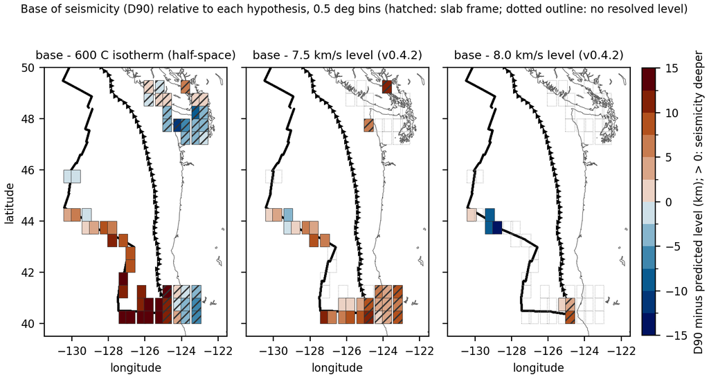

Frame units (segment-independent): D90 minus the 600 C half-space isotherm, minus the 7.5 km/s level and minus the 8.0 km/s level. Red: seismicity deeper than the level. Hatched: slab frame. Dotted: no resolved level. Colour map: vik (Crameri), diverging, colour-vision safe.

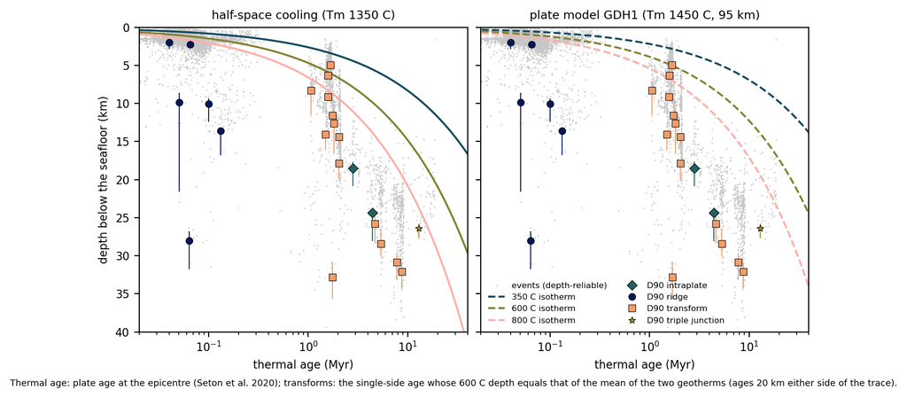

Depth below the seafloor against plate age with the 350/600/800 C isotherms. Grey: depth-reliable events. Symbols: unit D90 with the 95 % interval of the draws. The location Monte Carlo shifts the D90 draws deeper by a median 0.43 km (90th percentile 0.86 km) relative to the observed D90. That shift is the price of adding noise to noisy depths, so the central values are the observed D90.

Fact by fact:

- **Transforms** (14 units): the base is +7.8 km (95 % +7.5 to +10.1) below the 600 C half-space isotherm; all six isotherm variants are falsified. The temperature at the base is 1064 C (half-space). Old-side-only variant: +6.4 km. Blanco alone: +5.3 km. MFZ alone: +17.8 km.
- **Gorda plate interior** (2 units): +12.6 km (95 % +11.6 to +15.4) below the 600 C isotherm, at 1140 C.
- **Triple junction** (5 units): +10.3 km (95 % +7.2 to +12.3), at 874 C. Neither hypothesis fits: the 7.5 km/s level is +5.5 km off and does not follow.
- **Oceanic frame** (26 units, segment-independent): +9.5 km (95 % +9.3 to +12.5) for 600 C; +7.4 km (95 % +6.5 to +9.6) for 800 C; +4.9 km (95 % +3.0 to +6.4) for 7.5 km/s (19 units); -4.2 km (95 % -8.1 to +3.6) for 8.0 km/s (6 units).
- **Gorda slab** (11 units):
  - coldest-slab 600 C: -2.5 km (95 % -3.1 to -0.0);
  - GDH1 600 C: -0.7 km (95 % -1.2 to +1.6);
  - warm-top variant (labelled): +2.8 km;
  - 7.5 km/s: +5.0 km (95 % +2.7 to +6.7) (10 units).

  Below the Slab2 top, the base reaches 22-25 km in the bins where the slab is shallower than 13 km, near the deformation front, and 5-8 km where the slab is deeper than 20 km. This down-dip pattern is descriptive and was not registered.
- **Axial** (2 units): the base is within 3 km of all six isotherms (bias +1.1 km for 600 C). The isotherms there are 2-3 km below sea level at ages of 0.04-0.07 Myr, so this is not a test of a thermal limit.
- **Gorda Ridge** (4 units): D90 10-28 km below the seafloor at near-zero age, +10.5 km below 600 C. Not interpreted (see limitations).

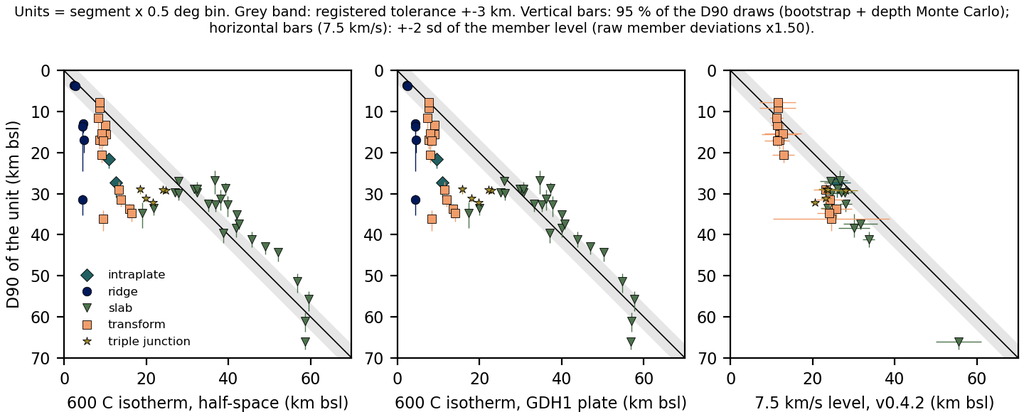

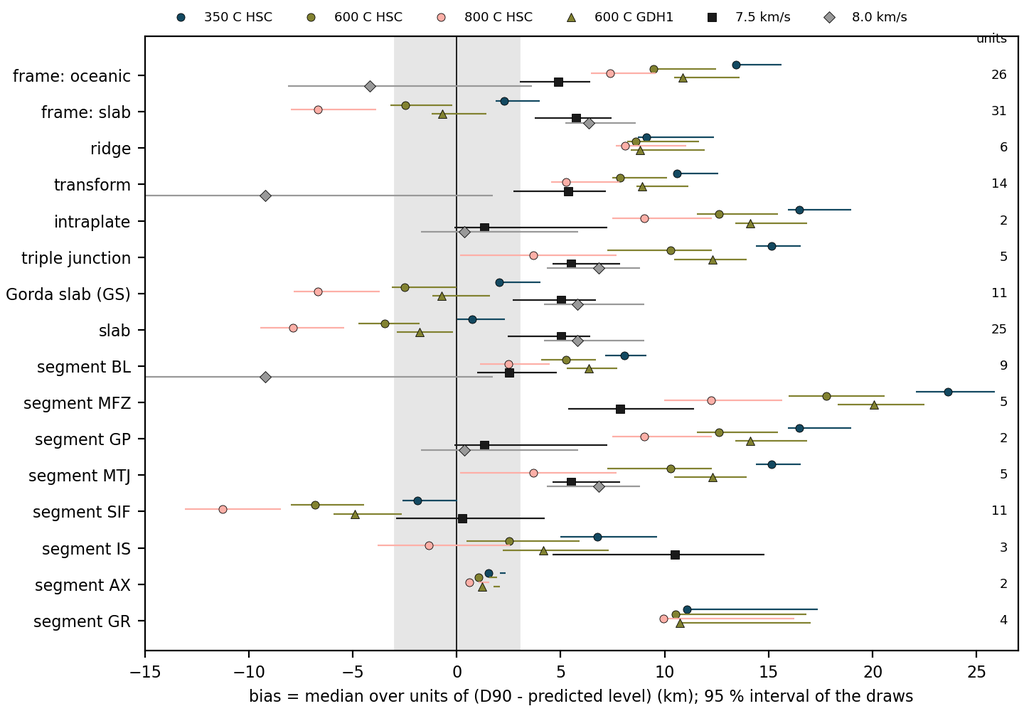

Bias per group and predictor: the median over units of D90 minus the level, with the 95 % interval of the draws. Grey band: the registered +-3 km tolerance. Right column: number of units.

### 4.2 Registered decisions (main configuration)

| group | n_units | n_units_T | n_units_C | T_sits | C_sits | T_follows | C_follows | T_falsified | C_falsified | answer |
| --- | --- | --- | --- | --- | --- | --- | --- | --- | --- | --- |
| ridge | 6 | 6 | 0 |  |  | False | False | True | False | H_T not supported; H_C not testable |
| ridge (no AX) | 4 | 4 | 0 |  |  | False | False | True | False | H_T not supported; H_C not testable |
| transform | 14 | 14 | 14 |  |  | True | True | True | False | composition-limited |
| intraplate | 2 | 2 | 1 |  | V7.5;V8.0 | False | False | True | False | composition-limited |
| triple junction | 5 | 5 | 5 |  |  | False | False | True | True | neither |
| slab | 25 | 25 | 12 | HSC_350;GDH1_350;GDH1_600 |  | True | True | False | False | composition-limited |
| Gorda slab (GS) | 11 | 11 | 10 | HSC_350;HSC_600;GDH1_600 |  | False | True | True | True | composition-limited |
| segment AX | 2 | 2 | 0 | HSC_350;HSC_600;HSC_800;GDH1_350;GDH1_600;GDH1_800 |  | False | False | False | False | H_T supported (H_C not testable) |
| segment GR | 4 | 4 | 0 |  |  | False | False | True | False | H_T not supported; H_C not testable |
| segment BL | 9 | 9 | 9 | HSC_800 | V7.5 | False | False | False | False | composition-limited |
| segment MFZ | 5 | 5 | 5 |  |  | False | False | True | False | neither |
| segment GP | 2 | 2 | 1 |  | V7.5;V8.0 | False | False | True | False | composition-limited |
| segment MTJ | 5 | 5 | 5 |  |  | False | False | True | True | neither |
| segment GS | 11 | 11 | 10 | HSC_350;HSC_600;GDH1_600 |  | False | True | True | True | composition-limited |
| segment SIF | 11 | 11 | 1 | HSC_350;GDH1_350 | V7.5 | True | False | False | False | both consistent |
| segment IS | 3 | 3 | 1 | HSC_600;HSC_800;GDH1_800 |  | False | False | False | False | H_T supported, not preferred |
| frame: oceanic | 26 | 26 | 19 |  | V8.0 | True | True | True | False | composition-limited |
| frame: slab | 31 | 31 | 13 | HSC_350;HSC_600;GDH1_600 |  | True | False | False | True | H_T supported, not preferred |
| frame: oceanic+slab | 57 | 57 | 32 | HSC_600;HSC_800;GDH1_800 | V8.0 | True | True | False | False | composition-limited |

frame: slab: the registered seed gives 'H_T supported, not preferred', but this answer sits at a decision threshold within Monte Carlo precision ('both consistent' in 14 of 20 seeds; 'H_T supported, not preferred' in 6 of 20 seeds; section 5a). Both readings stand.

Preference tests, on units that have both predictors. P_T is the share of draws with a smaller misfit for H_T. Primary pair: 600 C half-space against 7.5 km/s. The cv columns compare the cross-validated misfit.

| group | n_units_both | primary_P_T | primary_rms_T | primary_rms_C | primary_pref | best_of_family_P_T | best_of_family_pref | cv_P_T | cv_pref |
| --- | --- | --- | --- | --- | --- | --- | --- | --- | --- |
| transform | 14 | 0.00 | 12.26 | 6.55 | H_C | 0.66 | not distinguished | 0.01 | H_C |
| triple junction | 5 | 0.03 | 9.18 | 7.52 | H_C | 0.50 | not distinguished | 0.36 | not distinguished |
| slab | 12 | 0.57 | 5.96 | 6.08 | not distinguished | 0.19 | not distinguished | 0.00 | H_C |
| Gorda slab (GS) | 10 | 0.86 | 5.18 | 6.05 | not distinguished | 0.19 | not distinguished | 0.01 | H_C |
| segment BL | 9 | 0.02 | 6.78 | 4.90 | H_C | 0.66 | not distinguished | 0.45 | not distinguished |
| segment MFZ | 5 | 0.00 | 19.03 | 8.96 | H_C |  | not testable | 0.58 | not distinguished |
| segment MTJ | 5 | 0.03 | 9.18 | 7.52 | H_C | 0.50 | not distinguished | 0.36 | not distinguished |
| segment GS | 10 | 0.86 | 5.18 | 6.05 | not distinguished | 0.19 | not distinguished | 0.01 | H_C |
| frame: oceanic | 19 | 0.00 | 13.35 | 5.99 | H_C | 0.16 | not distinguished | 0.00 | H_C |
| frame: slab | 13 | 0.92 | 6.19 | 7.14 | H_T | 0.49 | not distinguished | 0.00 | H_C |
| frame: oceanic+slab | 32 | 0.00 | 11.18 | 6.56 | H_C | 0.54 | not distinguished | 0.00 | H_C |

**All group x predictor metrics (registered predictors and labelled variants)**

| group | level | n_units | bias | bias_lo95 | bias_hi95 | rms | abs_cat | span | rho | skill_med | P_skill_pos | shape_cat |
| --- | --- | --- | --- | --- | --- | --- | --- | --- | --- | --- | --- | --- |
| transform | HSC_350 | 14 | 10.58 | 10.48 | 12.56 | 16.05 | falsified | 3.69 | 0.72 | 0.11 | 1.00 | follows |
| transform | HSC_600 | 14 | 7.84 | 7.50 | 10.12 | 12.70 | falsified | 6.63 | 0.72 | 0.19 | 1.00 | follows |
| transform | HSC_800 | 14 | 5.26 | 4.54 | 7.82 | 9.42 | falsified | 9.70 | 0.79 | 0.29 | 1.00 | follows |
| transform | GDH1_350 | 14 | 11.15 | 11.12 | 13.13 | 16.75 | falsified | 3.04 | 0.69 | 0.09 | 1.00 | follows |
| transform | GDH1_600 | 14 | 8.91 | 8.64 | 11.15 | 13.98 | falsified | 5.48 | 0.72 | 0.16 | 1.00 | follows |
| transform | GDH1_800 | 14 | 6.85 | 6.35 | 9.20 | 11.36 | falsified | 7.84 | 0.76 | 0.24 | 1.00 | follows |
| transform | HSC_600_basement | 14 | 7.48 | 7.14 | 9.73 | 12.35 | falsified | 7.09 | 0.75 | 0.21 | 1.00 | follows |
| transform | HSC_600_young | 14 | 8.77 | 8.56 | 11.20 | 14.87 | falsified | 4.85 | 0.53 | 0.10 | 1.00 | follows |
| transform | HSC_600_old | 14 | 6.41 | 5.10 | 8.54 | 7.67 | falsified | 12.58 | 0.64 | 0.43 | 1.00 | follows |
| transform | EXT_HSC1300_600 | 14 | 10.86 | 10.93 | 12.43 | 14.92 | falsified | 5.88 | 0.21 | 0.14 | 1.00 | follows |
| transform | CRUST1_moho | 14 | 7.05 | 7.13 | 8.92 | 14.81 | falsified | 1.53 | -0.42 | -0.03 | 0.00 | not testable |
| transform | V7.5 | 14 | 5.35 | 2.72 | 7.18 | 6.32 | falsified | 13.03 | 0.82 | 0.51 | 1.00 | follows |
| transform | V8.0 | 4 | -9.21 | -18.22 | 1.72 | 14.53 | marginal | 17.02 | -0.32 | -2.26 | 0.04 | not testable |
| intraplate | HSC_350 | 2 | 16.49 | 15.93 | 18.99 | 16.66 | falsified | 0.73 |  | 0.14 | 0.95 | not testable |
| intraplate | HSC_600 | 2 | 12.61 | 11.56 | 15.45 | 12.76 | falsified | 1.40 |  | 0.28 | 0.96 | not testable |
| intraplate | HSC_800 | 2 | 9.02 | 7.48 | 12.28 | 9.15 | falsified | 2.04 |  | 0.40 | 0.97 | not testable |
| intraplate | GDH1_350 | 2 | 17.32 | 16.84 | 19.81 | 17.50 | falsified | 0.58 |  | 0.11 | 0.94 | not testable |
| intraplate | GDH1_600 | 2 | 14.13 | 13.40 | 16.86 | 14.29 | falsified | 1.14 |  | 0.22 | 0.96 | not testable |
| intraplate | GDH1_800 | 2 | 11.25 | 10.16 | 14.30 | 11.39 | falsified | 1.64 |  | 0.33 | 0.97 | not testable |
| intraplate | HSC_600_basement | 2 | 12.17 | 11.12 | 15.02 | 12.29 | falsified | 1.75 |  | 0.35 | 0.99 | not testable |
| intraplate | HSC_600_young | 2 | 12.61 | 11.56 | 15.45 | 12.76 | falsified | 1.40 |  | 0.28 | 0.96 | not testable |
| intraplate | HSC_600_old | 2 | 12.61 | 11.56 | 15.45 | 12.76 | falsified | 1.40 |  | 0.28 | 0.96 | not testable |
| intraplate | EXT_HSC1300_600 | 2 | 12.17 | 11.92 | 14.56 | 12.31 | falsified | 1.55 |  | 0.32 | 1.00 | not testable |
| intraplate | CRUST1_moho | 2 | 14.60 | 14.35 | 17.00 | 14.84 | falsified | 0.35 |  | 0.07 | 1.00 | not testable |
| intraplate | V7.5 | 1 | 1.34 | -0.10 | 7.24 | 1.34 | sits | 0.00 |  |  |  | not testable |
| intraplate | V8.0 | 1 | 0.37 | -1.71 | 5.84 | 0.37 | sits | 0.00 |  |  |  | not testable |
| triple junction | HSC_350 | 5 | 15.13 | 14.39 | 16.53 | 13.84 | falsified | 6.96 | 0.20 | -2.04 | 0.00 | does not follow |
| triple junction | HSC_600 | 5 | 10.27 | 7.24 | 12.26 | 8.79 | falsified | 5.42 | 0.20 | -1.03 | 0.01 | does not follow |
| triple junction | HSC_800 | 5 | 3.68 | 0.17 | 7.70 | 4.49 | marginal | 4.21 | -0.10 | -0.77 | 0.04 | does not follow |
| triple junction | GDH1_350 | 5 | 16.12 | 15.57 | 17.36 | 14.95 | falsified | 7.31 | 0.20 | -2.32 | 0.00 | does not follow |

[output cut: 96 more lines]

### 4.3 Temperature and velocity at the base

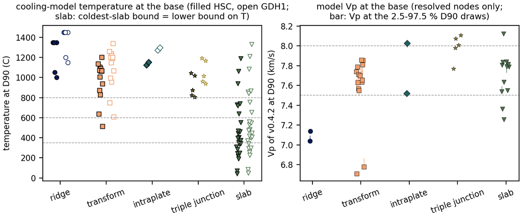

The cooling models put the base at 1064 C under the transforms, 1140 C under the Gorda plate and 874 C at the triple junction (half-space; GDH1 is 130-146 C hotter). All are outside 350-800 C. In the Gorda slab the coldest-slab bound gives 470 C, a lower bound on the temperature; the warm-top variant gives 718 C. The v0.4.2 Vp at the base (median per boundary type) is intraplate 7.77 km/s, ridge 7.09 km/s, slab 7.79 km/s, transform 7.68 km/s, triple junction 8.01 km/s. That is the uppermost mantle, or the crust-mantle transition, of the model.

### 4.4 Covariates (reported, not in the decisions)

Heat flow (GHFDB R2024) lies within 25 km of only 12 segment units. One is on the Gorda Ridge axis (5730 mW/m2, a hydrothermal value, not used below). The other 11 are near the margin or the triple junction, where heat flow is 34-82 mW/m2. That is far below the 200 mW/m2 or more that half-space cooling predicts for 5 Myr crust. A linear conductive geotherm from it puts 600 C at 23-55 km below the seafloor, close to or below the observed base. This is the direction a colder-than-conductive lithosphere would give. Shallow hydrothermal circulation also lowers measured heat flow on young crust, so the numbers do not separate the two. Sediment (GlobSed) is 0.0-1.0 km. Measuring the isotherms from the basement moves them by less than 1 km (oceanic-frame bias +9.3 km).

| key | lon | lat | D_bsf | q_mWm2 | q_n | z600_linear_bsf | sed_km |
| --- | --- | --- | --- | --- | --- | --- | --- |
| GR | -126.80 | 42.75 | 9.86 | 5730.00 | 2 | 0.33 | 0.04 |
| GS | -124.20 | 40.25 | 30.19 | 75.00 | 4 | 25.10 |  |
| GS | -124.20 | 40.75 | 26.83 | 49.00 | 9 | 38.42 | 0.60 |
| GS | -123.80 | 40.25 | 30.37 | 43.00 | 3 | 43.79 |  |
| GS | -123.80 | 40.75 | 29.57 | 49.00 | 1 | 38.42 |  |
| GS | -123.20 | 40.25 | 39.25 | 50.00 | 1 | 37.66 |  |
| IS | -123.80 | 49.25 | 65.61 | 38.00 | 3 | 49.55 | 0.93 |
| IS | -123.20 | 48.75 | 61.07 | 34.00 | 1 | 55.38 | 0.88 |
| MFZ | -125.20 | 40.25 | 32.09 | 82.00 | 1 | 22.96 | 0.67 |
| MTJ | -125.20 | 40.25 | 26.40 | 82.00 | 1 | 22.96 | 0.65 |
| MTJ | -124.20 | 40.25 | 29.31 | 75.00 | 4 | 25.10 | 0.61 |
| MTJ | -124.20 | 40.75 | 28.88 | 49.00 | 9 | 38.42 | 0.61 |

Labelled external-data variants (D-B114 job), main configuration:

- Half-space isotherms with Tm 1300 C and epicentral age: oceanic-frame bias +10.9 km.
- CRUST1.0 Moho, which does not come from the tomography: oceanic frame +6.9 km, Gorda slab +6.4 km. CRUST1.0 (1 deg) does not resolve variation between bins (span 2.2 km).
- Slab warm-top 600 C: slab frame +4.2 km, Gorda slab +2.8 km.

## 5. Controls

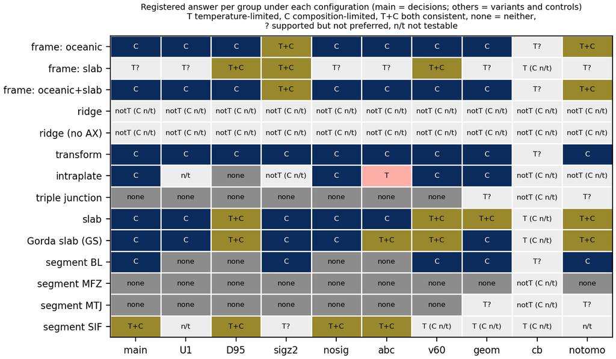

| group | units | answer_main | answer_changes_under_controls | H_T_falsified | H_T_falsification_changes | C3_flags | C5_on_7.5 | answer_robust | H_T_falsification_robust |
| --- | --- | --- | --- | --- | --- | --- | --- | --- | --- |
| frame: oceanic | 26 | composition-limited | sigz2: both consistent; cb: H_T supported, not preferred; notomo: both consistent | True | sigz2: False | C3 residual vs station distance (HSC_600, rho 0.75); C3 residual vs station distance (V7.5, rho 0.54) | C5b pass (rho 0.85, corrected 0.66, 90 % low 0.43); C5c pass (null p95 0.84; final) | False | False |
| frame: slab | 31 | H_T supported, not preferred | sigz2: both consistent; v60: both consistent; cb: H_T supported (H_C not testable) | False | notomo: True | none | C5b pass (rho 0.65, corrected 0.65, 90 % low 0.01); C5c pass (null p95 0.47; final) | False | False |
| frame: oceanic+slab | 57 | composition-limited | sigz2: both consistent; cb: H_T supported, not preferred; notomo: both consistent | False | none | C3 residual vs station distance (V7.5, rho 0.52) | C5b pass (rho 0.83, corrected 0.83, 90 % low 0.59); C5c pass (null p95 0.81; final) | False | False |
| ridge | 6 | H_T not supported; H_C not testable | none | True | none | none | not testable (< 5 units with a level) | True | True |
| ridge (no AX) | 4 | H_T not supported; H_C not testable | none | True | none | none | not testable (< 5 units with a level) | True | True |
| transform | 14 | composition-limited | cb: H_T supported, not preferred | True | sigz2: False; notomo: False | C3 residual vs station distance (HSC_600, rho 0.76); C3 residual vs station distance (V7.5, rho 0.73) | C5b pass (rho 0.82, corrected 0.82, 90 % low 0.55); C5c pass (null p95 0.74; final) | False | False |
| intraplate | 2 | composition-limited | sigz2: H_T not supported; H_C not testable; cb: H_T not supported; H_C not testable; notomo: H_T not supported; H_C not testable | True | none | none | not testable (< 5 units with a level) | False | True |
| triple junction | 5 | neither | geom: H_T supported, not preferred; cb: H_T not supported; H_C not testable; notomo: H_T supported, not preferred | True | geom: False; notomo: False | C3 residual vs station distance (V7.5, rho -0.30) | C5b fail (rho -0.60, corrected -0.60, 90 % low -0.80); C5c fail (null p95 -0.10; final) | False | False |
| slab | 25 | composition-limited | v60: both consistent; geom: both consistent; cb: H_T supported (H_C not testable); notomo: both consistent | False | none | C3 residual vs station distance (V7.5, rho 0.62) | C5b pass (rho 0.70, corrected 0.70, 90 % low 0.06); C5c pass (null p95 0.50; final) | False | False |
| Gorda slab (GS) | 11 | composition-limited | v60: both consistent; cb: H_T supported (H_C not testable); notomo: both consistent | True | notomo: False | C3 residual vs station distance (V7.5, rho 0.43) | C5b fail (rho 0.66, corrected 0.66, 90 % low -0.35); C5c pass (null p95 0.58; final) | False | False |
| segment AX | 2 | H_T supported (H_C not testable) | none | False | none | none | not testable (< 5 units with a level) | True | False |
| segment GR | 4 | H_T not supported; H_C not testable | none | True | none | none | not testable (< 5 units with a level) | True | True |
| segment BL | 9 | composition-limited | nosig: neither; cb: H_T supported, not preferred | False | nosig: True | none | C5b pass (rho 0.41, corrected 0.41, 90 % low 0.15); C5c fail (null p95 0.48; final) | False | False |
| segment MFZ | 5 | neither | cb: H_T not supported; H_C not testable | True | none | none | C5b fail (rho 0.50, corrected 0.50, 90 % low -0.67); C5c fail (null p95 0.68; provisional (9 of >= 15 members)) | False | True |
| segment GP | 2 | composition-limited | sigz2: H_T not supported; H_C not testable; cb: H_T not supported; H_C not testable; notomo: H_T not supported; H_C not testable | True | none | none | not testable (< 5 units with a level) | False | True |
| segment MTJ | 5 | neither | geom: H_T supported, not preferred; cb: H_T not supported; H_C not testable; notomo: H_T supported, not preferred | True | geom: False; notomo: False | C3 residual vs station distance (V7.5, rho -0.30) | C5b fail (rho -0.60, corrected -0.60, 90 % low -0.80); C5c fail (null p95 -0.10; final) | False | False |
| segment GS | 11 | composition-limited | v60: both consistent; cb: H_T supported (H_C not testable); notomo: both consistent | True | notomo: False | C3 residual vs station distance (V7.5, rho 0.43) | C5b fail (rho 0.66, corrected 0.66, 90 % low -0.35); C5c pass (null p95 0.58; final) | False | False |
| segment SIF | 11 | both consistent | sigz2: H_T supported, not preferred; v60: H_T supported (H_C not testable); geom: H_T supported (H_C not testable); cb: H_T supported (H_C not testable); notomo: absent | False | none | none | not testable (< 5 units with a level) | False | False |
| segment IS | 3 | H_T supported, not preferred | cb: H_T supported (H_C not testable); notomo: absent | False | none | none | not testable (< 5 units with a level) | False | False |

Reading the table:

- **C4 (mask)**: with the checkerboard-only mask, no offshore unit has a 7.5 or 8.0 km/s crossing between two resolved nodes. Every velocity level used here comes from the DWS >= 100 part of the mask, so every H_C result is mask-sensitive.
- **C3 (geometry)**: in the oceanic frame the residual grows with the distance to the nearest station, for the isotherm (rho 0.75) and for the 7.5 km/s level (rho 0.54). The Mendocino-Gorda bins are both the deepest and the farthest from stations. Restricting to events with a station within one focal depth (geom) gives an isotherm bias of +9.1 km (600 C) and a 7.5 km/s bias of +3.6 km.
- **C1, C2**: the H_T falsification in the oceanic frame holds under the registered controls except sig_z <= 2 km (800 C half-space isotherm +4.6 km, marginal). For the MFZ it holds under every registered control, and for the Gorda plate interior it holds under every registered control.
- **C5a**: without the inverted events (17 oceanic units, 11 with a level), the 7.5 km/s bias is +3.7 km; shape: follows. The base still follows the level.

### Circularity of the velocity levels (C5b, C5c)

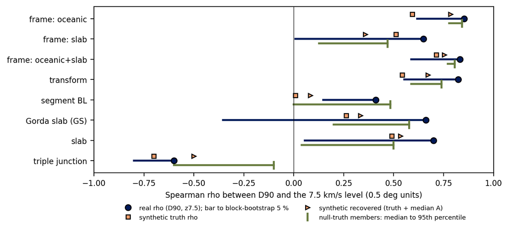

| group | level | n_units | rho_real | rho_real_lo90 | rho_truth | A_median | A_share_pos | C5b_flag | rho_corrected | rho_corrected_lo90 | C5b_pass | rho_null_truth | rho_null_median | rho_null_p95 | n_null_valid | C5c_pass | C5c_status |
| --- | --- | --- | --- | --- | --- | --- | --- | --- | --- | --- | --- | --- | --- | --- | --- | --- | --- |
| transform | V7.5 | 14 | 0.82 | 0.55 | 0.54 | 0.13 | 0.79 | False | 0.82 | 0.55 | True | 0.52 | 0.59 | 0.74 | 20.00 | True | final |
| triple junction | V7.5 | 5 | -0.60 | -0.80 | -0.70 | 0.20 | 0.63 | False | -0.60 | -0.80 | False | 0.71 | -0.60 | -0.10 | 20.00 | False | final |
| slab | V7.5 | 12 | 0.70 | 0.06 | 0.49 | 0.04 | 0.67 | False | 0.70 | 0.06 | True |  | 0.04 | 0.50 | 20.00 | True | final |
| Gorda slab (GS) | V7.5 | 10 | 0.66 | -0.35 | 0.26 | 0.07 | 0.72 | False | 0.66 | -0.35 | False |  | 0.20 | 0.58 | 20.00 | True | final |
| segment BL | V7.5 | 9 | 0.41 | 0.15 | 0.01 | 0.08 | 0.62 | False | 0.41 | 0.15 | True |  | 0.00 | 0.48 | 20.00 | False | final |
| segment MFZ | V7.5 | 5 | 0.50 | -0.67 | 1.00 | -0.60 | 0.00 | False | 0.50 | -0.67 | False |  | -0.20 | 0.68 | 9.00 | False | provisional (9 of >= 15 members) |
| segment MTJ | V7.5 | 5 | -0.60 | -0.80 | -0.70 | 0.20 | 0.63 | False | -0.60 | -0.80 | False | 0.71 | -0.60 | -0.10 | 20.00 | False | final |
| segment GS | V7.5 | 10 | 0.66 | -0.35 | 0.26 | 0.07 | 0.72 | False | 0.66 | -0.35 | False |  | 0.20 | 0.58 | 20.00 | True | final |
| frame: oceanic | V7.5 | 19 | 0.85 | 0.62 | 0.59 | 0.19 | 0.97 | True | 0.66 | 0.43 | True | 0.76 | 0.78 | 0.84 | 20.00 | True | final |
| frame: oceanic | V8.0 | 6 | 0.29 | -0.64 | 0.43 | -0.07 | 0.17 | False | 0.29 | -0.64 | False |  | 0.68 | 0.95 | 20.00 | False | final |
| frame: slab | V7.5 | 13 | 0.65 | 0.01 | 0.51 | -0.15 | 0.07 | False | 0.65 | 0.01 | True | 0.26 | 0.13 | 0.47 | 20.00 | True | final |
| frame: oceanic+slab | V7.5 | 32 | 0.83 | 0.59 | 0.71 | 0.04 | 0.87 | False | 0.83 | 0.59 | True | 0.83 | 0.77 | 0.81 | 20.00 | True | final |
| frame: oceanic+slab | V8.0 | 8 | 0.35 | -0.60 | 0.49 | -0.01 | 0.40 | False | 0.35 | -0.60 | False |  | 0.55 | 0.86 | 20.00 | False | final |

The synthetic members (truth = v0.4.2 perturbed) recover levels 0.4-1.0 km shallower than the truth in the oceanic units. In the oceanic frame they increase the D90-level correlation by 0.19 (97 % of members positive). The correction leaves rho 0.66, with a 90 % lower bound of 0.43.

The null-truth members (20 of 20 merged at the time of this report) give rho 0.78 (median) to 0.84 (95th percentile) in the oceanic frame, against the real 0.85. The null truth flattens structure only within each segment's zone, so the contrast between the Blanco and Mendocino-Gorda zones survives in it (null-truth rho 0.76). The real correlation is therefore hardly larger than what the zone means plus the ray coverage produce.

For the Gorda slab the real rho 0.66 exceeds the null 95th percentile (0.58) by 0.08. Its 4 one-degree blocks give a block-bootstrap lower bound of -0.35. The earlier column result (rho 0.53, p 0.001) treated 67 columns as independent at a 40 km model resolution. With 0.5 deg bins and block resampling it is not significant. The null-truth control C5c is scored on 20 of 20 merged members, which meets the registered minimum of 15. A group whose own valid member count is below 15 stays provisional (C5c_status column). To rescore: `bash workflow/11_paper_plan/run_q2.sh circ`.

### Not registered: within-cluster correlations

| cluster | level | n_units | rho | bias | D_range | level_range |
| --- | --- | --- | --- | --- | --- | --- |
| Blanco cluster (oceanic, lat >= 42.5) | HSC_600 | 12 | 0.68 | 4.31 | 17.04 | 5.87 |
| Blanco cluster (oceanic, lat >= 42.5) | GDH1_600 | 12 | 0.69 | 5.31 | 17.04 | 5.26 |
| Blanco cluster (oceanic, lat >= 42.5) | HSC_800 | 12 | 0.62 | 1.76 | 17.04 | 7.52 |
| Blanco cluster (oceanic, lat >= 42.5) | V7.5 | 9 | 0.41 | 2.51 | 12.82 | 1.66 |
| Mendocino-Gorda cluster (oceanic, lat < 42.5) | HSC_600 | 14 | 0.38 | 15.53 | 23.27 | 19.25 |
| Mendocino-Gorda cluster (oceanic, lat < 42.5) | GDH1_600 | 14 | 0.38 | 17.27 | 23.27 | 15.78 |
| Mendocino-Gorda cluster (oceanic, lat < 42.5) | HSC_800 | 14 | 0.38 | 11.14 | 23.27 | 27.45 |
| Mendocino-Gorda cluster (oceanic, lat < 42.5) | V7.5 | 10 | 0.41 | 5.79 | 11.05 | 3.33 |
| oceanic frame, all | HSC_600 | 26 | 0.60 | 9.48 | 32.65 | 19.25 |
| oceanic frame, all | GDH1_600 | 26 | 0.60 | 10.88 | 32.65 | 15.78 |
| oceanic frame, all | HSC_800 | 26 | 0.59 | 7.37 | 32.65 | 27.45 |
| oceanic frame, all | V7.5 | 19 | 0.85 | 4.88 | 28.43 | 14.63 |

Within the Blanco bins and within the Mendocino-Gorda bins, D90 correlates with each predictor at rho 0.38-0.69 (9-14 units). For the 7.5 km/s level the within-cluster rho is 0.41 and 0.41 (Blanco, Mendocino-Gorda), against 0.85 for the whole oceanic frame: most of that correlation comes from the difference between the two clusters.

### 5a. Monte Carlo precision of the registered probabilities

Coordinator check after the final report; no rule changed. The slab-frame answer changed between the D-B113 and v2 runs only through the draw sequence, so the main configuration was rerun with 20 independent seeds (SEED + 5000 + k) at the registered 1000 draws. The table lists every registered probability that lies within 0.03 of its threshold in the registered run: P_sit (sits if >= 0.5), P_far (falsified if >= 0.95), P_skill_pos (follows if >= 0.9, does not follow if <= 0.1) and preference P_T (>= 0.9 or <= 0.1). The last column is the draw count at which the seed SD would be half the distance between the seed mean and the threshold (SD scales as 1/sqrt(draws)). It is a precision note only; the registered count stays 1000.

| group | item | prob | threshold | registered | n_seeds | mean | sd | min | max | share_at_or_above | straddles | draws_for_2sd |
| --- | --- | --- | --- | --- | --- | --- | --- | --- | --- | --- | --- | --- |
| Gorda slab (GS) | GDH1_350 | P_far | 0.95 | 0.974 | 20 | 0.969 | 0.006 | 0.960 | 0.983 | 1.00 | False | 369 |
| Gorda slab (GS) | GDH1_800 | P_sit | 0.50 | 0.470 | 20 | 0.450 | 0.012 | 0.427 | 0.470 | 0.00 | False | 247 |
| Gorda slab (GS) | V7.5 | P_far | 0.95 | 0.953 | 20 | 0.952 | 0.005 | 0.943 | 0.962 | 0.70 | True | 25,579 |
| frame: oceanic | V7.5 | P_far | 0.95 | 0.978 | 20 | 0.981 | 0.005 | 0.973 | 0.991 | 1.00 | False | 114 |
| frame: oceanic+slab | GDH1_600 | P_far | 0.95 | 0.953 | 20 | 0.940 | 0.007 | 0.922 | 0.948 | 0.00 | False | 1,852 |
| frame: oceanic+slab | V8.0 | P_skill_pos | 0.90 | 0.892 | 20 | 0.891 | 0.006 | 0.882 | 0.901 | 0.15 | True | 1,836 |
| frame: slab | GDH1_350 | P_far | 0.95 | 0.965 | 20 | 0.959 | 0.008 | 0.934 | 0.967 | 0.95 | True | 3,007 |
| frame: slab | V7.5 | P_skill_pos | 0.90 | 0.885 | 20 | 0.905 | 0.007 | 0.892 | 0.915 | 0.70 | True | 9,813 |
| frame: slab | preference | primary_P_T | 0.90 | 0.919 | 20 | 0.926 | 0.010 | 0.910 | 0.942 | 1.00 | False | 602 |
| segment BL | GDH1_800 | P_far | 0.95 | 0.968 | 20 | 0.967 | 0.006 | 0.950 | 0.977 | 1.00 | False | 559 |
| segment GS | GDH1_350 | P_far | 0.95 | 0.974 | 20 | 0.969 | 0.006 | 0.960 | 0.983 | 1.00 | False | 369 |
| segment GS | GDH1_800 | P_sit | 0.50 | 0.470 | 20 | 0.450 | 0.012 | 0.427 | 0.470 | 0.00 | False | 247 |
| segment GS | V7.5 | P_far | 0.95 | 0.953 | 20 | 0.952 | 0.005 | 0.943 | 0.962 | 0.70 | True | 25,579 |
| segment IS | HSC_600 | P_sit | 0.50 | 0.523 | 20 | 0.532 | 0.018 | 0.496 | 0.573 | 0.95 | True | 1,217 |
| segment SIF | GDH1_600 | P_far | 0.95 | 0.927 | 20 | 0.932 | 0.008 | 0.915 | 0.948 | 0.00 | False | 758 |
| transform | V7.5 | P_far | 0.95 | 0.961 | 20 | 0.969 | 0.005 | 0.957 | 0.978 | 1.00 | False | 269 |

Registered answers that change between seeds (count of seeds per answer):

| group | answer | n_seeds | registered_answer |
| --- | --- | --- | --- |
| frame: slab | H_T supported, not preferred | 6 | H_T supported, not preferred |
| frame: slab | both consistent | 14 | H_T supported, not preferred |

frame: slab: 'both consistent' in 14 of 20 seeds; 'H_T supported, not preferred' in 6 of 20 seeds. Probabilities whose seed range straddles the threshold: Gorda slab (GS) V7.5 P_far (mean 0.952, SD 0.005, 0.943-0.962, threshold 0.95); frame: oceanic+slab V8.0 P_skill_pos (mean 0.891, SD 0.006, 0.882-0.901, threshold 0.90); frame: slab GDH1_350 P_far (mean 0.959, SD 0.008, 0.934-0.967, threshold 0.95); frame: slab V7.5 P_skill_pos (mean 0.905, SD 0.007, 0.892-0.915, threshold 0.90); segment GS V7.5 P_far (mean 0.952, SD 0.005, 0.943-0.962, threshold 0.95); segment IS HSC_600 P_sit (mean 0.532, SD 0.018, 0.496-0.573, threshold 0.50).

The other 5 straddling probabilities do not change any registered answer: another predictor or test of the same rule already decides it. The deciding probability of the frame: slab answer is V7.5 P_skill_pos (seed mean 0.905, SD 0.007, threshold 0.90, 70 % of seeds at or above it). Resolving it at 2 SD would take about 9,813 draws per run. The registered draw count stays 1000.

### 5b. Post-registration control L: are our depths too deep?

- L1 subtracts each event's regional offset before D90: Blanco segments by longitude, and the Blanco-wide value elsewhere. Variants:
  - lit_med: median offsets;
  - lit_p90: p90 offsets, the worst case;
  - lit_gd: lit_med, but with the Gorda Depression median for the Mendocino-Gorda system.

  Segments, frames and predictors are those of the unshifted events.
- L2 recomputes D90 from Lange's depths for our Blanco events paired with his absolute catalog (lange). The same events with our depths are lange_ours. Lange's datum is read as km below sea level, as in b4_lit_paired.py; if it were below the seafloor, his depths would be about 3 km deeper in our frame.

| group | main | lit_med | lit_gd | lit_p90 | lange_ours | lange | shift that fits 800 C |
| --- | --- | --- | --- | --- | --- | --- | --- |
| frame: oceanic | 600 +9.5 / 800 +7.4; H_T falsified (26 units) | 600 +6.3 / 800 +4.2; H_T falsified (26 units) | 600 +3.1 / 800 +0.2; H_T not falsified (26 units) | 600 -0.4 / 800 -2.5; H_T not falsified (26 units) |  |  | 4.4 km |
| transform | 600 +7.8 / 800 +5.3; H_T falsified (14 units) | 600 +4.0 / 800 +1.4; H_T not falsified (14 units) | 600 +4.0 / 800 +1.2; H_T not falsified (14 units) | 600 -2.5 / 800 -5.0; H_T not falsified (14 units) |  |  | 2.3 km |
| segment BL | 600 +5.3 / 800 +2.5; H_T not falsified (9 units) | 600 +1.7 / 800 -0.6; H_T not falsified (9 units) | 600 +1.7 / 800 -0.6; H_T not falsified (9 units) | 600 -4.1 / 800 -6.6; H_T not falsified (9 units) | 600 +4.5 / 800 +1.9; H_T not falsified (8 units) | 600 +1.2 / 800 -1.2; H_T not falsified (8 units) | -0.5 km |
| segment MFZ | 600 +17.8 / 800 +12.2; H_T falsified (5 units) | 600 +14.6 / 800 +9.1; H_T falsified (5 units) | 600 +8.2 / 800 +2.6; H_T not falsified (5 units) | 600 +7.9 / 800 +2.3; H_T not falsified (5 units) |  |  | 9.2 km |
| intraplate | 600 +12.6 / 800 +9.0; H_T falsified (2 units) | 600 +9.4 / 800 +5.9; H_T falsified (2 units) | 600 +3.0 / 800 -0.6; H_T not falsified (2 units) | 600 +2.7 / 800 -0.9; H_T not falsified (2 units) |  |  | 6.0 km |
| triple junction | 600 +10.3 / 800 +3.7; H_T falsified (5 units) | 600 +7.1 / 800 +0.5; H_T falsified (5 units) | 600 +0.7 / 800 -5.9; H_T falsified (5 units) | 600 +0.4 / 800 -6.2; H_T falsified (5 units) |  |  | 0.7 km |
| Gorda slab (GS) | 600 -2.5 / 800 -6.7; H_T falsified (11 units) | 600 -5.7 / 800 -9.9; H_T falsified (11 units) | 600 -12.1 / 800 -16.3; H_T falsified (11 units) | 600 -12.4 / 800 -16.6; H_T falsified (11 units) |  |  | -9.7 km |
| frame: slab | 600 -2.5 / 800 -6.7; H_T not falsified (31 units) | 600 -5.7 / 800 -9.9; H_T not falsified (31 units) | 600 -6.8 / 800 -11.1; H_T not falsified (31 units) | 600 -12.4 / 800 -16.6; H_T falsified (31 units) |  |  | -9.7 km |

Each cell gives the bias of D90 against the 600 C and 800 C half-space isotherms (km; positive = base deeper) and the registered H_T verdict. The last column is the extra depth bias that would bring the 800 C isotherm within the 3 km tolerance: main bias minus 3 km.

**Verdict.** The headline 'D90 7-14 km below all conductive isotherms' does not survive as stated.

- **Velocity levels move too**: with the median offsets the oceanic-frame base sits at the 7.5 km/s level (+1.2 km, was +4.9). So 'about 5 km below 7.5 km/s' also depends on the depth bias.
- **Median offsets**: the oceanic-frame rejection of 350-800 C holds; the bias to 800 C drops from +7.4 to +4.2 km. It also holds for the Gorda plate interior, the MFZ and the triple junction (the triple junction through the shape rule). It fails for the transforms as a group.
- **Blanco (L2)**: Lange's depths put the base within 3 km of the 600 and 800 C mean-geotherm isotherms. The excess depth at Blanco is the known depth bias, not a deep brittle layer.
- **Worst-case offsets** (p90 everywhere, or the Gorda Depression value in the Mendocino-Gorda system): the 800 C isotherm fits the oceanic frame and the rejection fails.
- **What can be stated**: in the Gorda plate interior and the MFZ the seismicity base lies 9-12 km below the 800 C isotherm. A temperature limit of at most 800 C would need our depths there to be 6-9 km too deep. That is 2-3 times the Blanco median offset (3.2 km), and of the size of the one paired value nearby (Gorda Depression, 9.6 km).

### 5c. Plate boundaries v2 (D-B117) against the D-B113 run

Everything above uses the adopted plate boundaries v2. The first report used the D-B113 axes. The rules, configurations and controls are the same. Each cell reads 'D-B113 run -> v2 run' (main configuration; biases in km against the half-space isotherms and the 7.5 km/s level; H_T verdict of the registered rule, also under the median and p90 literature offsets).

| group | units | answer | H_T_falsified | bias_600 | bias_800 | bias_7p5 | H_T_falsified_lit_med | H_T_falsified_lit_p90 |
| --- | --- | --- | --- | --- | --- | --- | --- | --- |
| frame: oceanic | 26 -> 26 | composition-limited -> composition-limited | True -> True | +10.8 -> +9.5 | +8.1 -> +7.4 | +4.9 -> +4.9 | True -> True | False -> False |
| frame: slab | 31 -> 31 | both consistent -> H_T supported, not preferred | False -> False | -2.5 -> -2.5 | -6.7 -> -6.7 | +5.7 -> +5.7 | False -> False | True -> True |
| transform | 14 -> 14 | composition-limited -> composition-limited | True -> True | +7.5 -> +7.8 | +4.9 -> +5.3 | +5.4 -> +5.4 | False -> False | False -> False |
| segment BL | 9 -> 9 | composition-limited -> composition-limited | False -> False | +5.4 -> +5.3 | +2.7 -> +2.5 | +2.5 -> +2.5 | False -> False | False -> False |
| segment MFZ | 5 -> 5 | neither -> neither | True -> True | +17.7 -> +17.8 | +11.8 -> +12.2 | +7.9 -> +7.9 | True -> True | False -> False |
| intraplate | 3 -> 2 | composition-limited -> composition-limited | True -> True | +13.7 -> +12.6 | +9.9 -> +9.0 | +1.8 -> +1.3 | True -> True | False -> False |
| triple junction | 5 -> 5 | neither -> neither | True -> True | +10.3 -> +10.3 | +3.7 -> +3.7 | +5.5 -> +5.5 | True -> True | True -> True |
| Gorda slab (GS) | 11 -> 11 | composition-limited -> composition-limited | True -> True | -2.5 -> -2.5 | -6.7 -> -6.7 | +5.0 -> +5.0 | True -> True | True -> True |
| ridge (no AX) | 4 -> 4 | H_T not supported; H_C not testable -> H_T not supported; H_C not testable | True -> True | +10.5 -> +10.5 | +9.9 -> +9.9 | +nan -> +nan | True -> True | False -> False |

Registered answers that changed: frame: slab: both consistent -> H_T supported, not preferred. Components that moved: frame: slab: V7.5 shape follows -> undetermined (P 0.900 -> 0.885). Where the unit data did not change (the slab frame does not use the segments), the shift comes from the Monte Carlo draw sequence: one segment unit fewer precedes the frame units, so their draws differ. A probability at the 0.9 threshold can then fall on either side. H_T verdicts that changed (main): none.

## 6. What the paper can claim, and what it cannot

### Can claim

- In the Gorda plate interior and along the Mendocino fault zone (Gorda plate ages up to ~4 Myr; Pacific side of the MFZ 15-20 Myr), located earthquakes extend 9-12 km below the 800 C isotherm of half-space and GDH1 cooling models of their Seton et al. (2020) plate age. Transform ages are taken on both sides. A 350-800 C conductive limit there needs our depths to be 6-9 km too deep; the median depth offset measured at Blanco is 3.2 km.
  - In the oceanic frame (26 bins) no isotherm from 350 to 800 C fits the base within 3 km.
  - This holds under the registered controls except sig_z <= 2 km (800 C half-space isotherm +4.6 km, marginal); the external-data isotherms (Tm 1300 C) give the same. For the transforms alone, the 800 C isotherm is not rejected with sig_z <= 2 km or with events not in the tomography; the 600 C isotherm is rejected in every control.
- With the median literature offsets the oceanic-frame rejection still holds (control L1).

So, unless those depths are biased by 6 km or more, the depth limit there is not a conductive-cooling isotherm of the standard brittle range.

At Blanco, Lange's OBS depths put the base within 3 km of the 600-800 C isotherms of the two-sided transform geotherm (control L2).

In the oceanic plates the base lies at or below the 7.5 km/s level of v0.4.2. With our depths it is 5 km below it in the oceanic frame (5.4 km at the transforms, 5.5 km at the triple junction), above the 8.0 km/s level where it is resolved, and 6-7 km below the CRUST1.0 Moho (oceanic frame, Gorda slab). With the median literature offsets it sits at the 7.5 km/s level (+1.2 km).

In the subducting Gorda slab the base lies between the 600 C isotherms of a coldest-slab bound and a warm-top variant. This is consistent with a thermal limit near 600-700 C, with the stated slab-model simplifications.

### Cannot claim

- A single answer for the frame: slab: it sits at a registered threshold within Monte Carlo precision ('both consistent' in 14 of 20 seeds; 'H_T supported, not preferred' in 6 of 20 seeds). Both readings are stated.
- That earthquakes go deeper than conductive isotherms at Blanco, or across all transforms. With Lange's depths, or with the median offsets, the 800 C isotherm fits.
- That the rejection holds under any plausible depth bias. With the p90 offsets, or the Gorda Depression offset moved to the Mendocino-Gorda system, the 800 C isotherm fits the oceanic frame.
- That the base follows the 7.5 km/s level (composition control). The following comes from the Blanco versus Mendocino-Gorda contrast, and it fails three registered controls:
  - no level is checkerboard-resolved (C4);
  - the residuals correlate with station distance (C3);
  - the Gorda-slab correlation fails C5b (C5c: it exceeds the null 95th percentile (0.58) by 0.08), and the oceanic-frame correlation passes C5c by 0.01 with 20 members.
- Which of composition or a colder-than-conductive lithosphere (deep hydrothermal cooling, compression of the Gorda plate) sets the limit in the oceanic plates. The measured heat flow is consistent with a colder plate, but too sparse to decide.
- Anything about ridge depth limits: Axial is biased, and the Gorda Ridge and other ridges are poorly constrained.
- A down-dip thermal control within the Gorda slab: no registered shape test passes there.
- The Juan de Fuca plate interior (no unit) and the Explorer region (no depth-reliable events).

## 7. Manuscript bullets

- Q2 test, pre-registered: depth-reliable v6.1 events (tier A-B, sig_z <= 3 km); D90 per 0.5 deg bin with bootstrap and location Monte Carlo. Compared with 350/600/800 C isotherms (half-space, GDH1; Seton et al. 2020 ages; transforms: mean of both sides) and with the 7.5/8.0 km/s levels of v0.4.2 (ensemble spread x1.5). Tolerance 3 km.
- Oceanic plates (all 0.5 deg bins west of the trench: ridges, transforms, Gorda plate, triple junction): D90 lies 9 km below the 600 C half-space isotherm (median of 26 bins; 95 % 9-12 km). The base is at about 1064 C in the cooling model. No 350-800 C isotherm fits within 3 km. This holds under the registered controls except sig_z <= 2 km (800 C half-space isotherm +4.6 km, marginal); in the Gorda plate interior and the MFZ it holds under every registered control.
- Depth-bias check: removing the median offset against the Blanco OBS catalog (+3.2 km) keeps the rejection in the Gorda plate interior and the MFZ: the base is 6-9 km below 800 C. At Blanco, the OBS catalog's own depths put the base at the 600-800 C isotherms of the two-sided transform geotherm.
- Same plates: D90 lies 5 km below the 7.5 km/s level (19 bins; +1.2 km after the median literature offset) and 4 km above the 8.0 km/s level where that level is resolved (6 bins). Earthquakes reach at least the 7.5 km/s level of the model.
- The apparent link between the seismicity base and the 7.5 km/s level is limited by three things: the Blanco versus Mendocino-Gorda contrast, levels resolved only by ray density (not checkerboard), and residuals that grow with station distance. It is not used as evidence for a compositional limit.
- Gorda slab: D90 lies between the 600 C isotherms of a coldest-slab bound (-2.5 km) and a warm-top variant using the slab-surface temperature of van Keken & Wilson (2023) (+2.8 km). This is consistent with a 600-700 C limit.
- Heat flow near the triple junction and the margin (34-82 mW/m2) is far below the cooling-model value for 5 Myr crust. That is consistent with a plate colder than conductive cooling predicts, but the measurements are too sparse to test.
- Monte Carlo precision: the frame: slab answer sits at a registered threshold ('both consistent' in 14 of 20 seeds; 'H_T supported, not preferred' in 6 of 20 seeds, 20 independent seeds of 1000 draws); both readings are reported.
- Ridge depth limits are not interpreted: Axial depths carry the SSST bias, and other ridge depths are unconstrained.

## 8. Limitations

- Axial depths carry the known SSST bias (D-B100/D-B103): 72.7 % of tier A-B Axial events are within 2 km of the seafloor, against 90 % in Waldhauser et al. (2020). Cooling models do not describe the axial magma system.
- Ridge depths other than Axial are poorly constrained:
  - depth_quality is 'unconstrained' for the ridge regions;
  - the 244 depth-reliable Gorda Ridge events give D90 10-28 km below the seafloor at near-zero age, which this report does not interpret.
- Our depths are deeper than local OBS catalogs: +3.17 km median (tier A-B) at Blanco against Lange et al. (2026), +9.6 km at the Gorda Depression (23 events), +0.85 km at Mount St Helens. There is no paired reference for the Gorda plate, the MFZ, the triple junction or the Gorda slab. The Mendocino-Gorda result rests on depths that no local catalog has checked.
- Model resolution is about 40 km laterally. Depth nodes are 3-6 km apart at 15-35 km. No 7.5 or 8.0 km/s crossing offshore lies between checkerboard-resolved nodes.
- The velocity levels come from an inversion of the same events. The circularity controls reduce but do not remove this dependence. The null-truth control C5c is scored on 20 of 20 merged members, which meets the registered minimum of 15. A group whose own valid member count is below 15 stays provisional (C5c_status column).
- Cooling-model assumptions: conductive cooling from a seafloor at 0 C. There is no hydrothermal cooling, no shear or frictional heating on transforms, no sediment blanketing and no plate compression. Transforms use the mean of two one-sided geotherms. Ages come from a global grid that smooths the Mendocino age step over about 0.1 deg.
- The slab isotherms are bounds, not a slab thermal model:
  - the incoming geotherm is hung below Slab2 with a 0 C top (coldest slab);
  - the warm-top variant uses the slab-surface temperature of the 2-D North and Central Cascadia models, not their interior temperatures.
- Small samples: 2 Gorda-plate units, 5 MFZ units, 5 triple-junction units and 4 Gorda-slab 1-degree blocks. The 0.5 deg units are still not independent at a 40 km resolution.
- The depth Monte Carlo adds noise to depths that already contain it, which shifts the D90 draws about 0.4 km deeper. The intervals are therefore slightly wide on the deep side.

## References

- Bird, P. (2003). An updated digital model of plate boundaries. G-cubed 4, 1027.
- Boettcher, M. S., & Jordan, T. H. (2004). Earthquake scaling relations for mid-ocean ridge transform faults. JGR 109, B12302.
- Hayes, G. P., et al. (2018). Slab2, a comprehensive subduction zone geometry model. Science 362, 58-61.
- Laske, G., et al. (2013). Update on CRUST1.0. EGU General Assembly abstract.
- Seton, M., et al. (2020). A global data set of present-day oceanic crustal age and seafloor spreading parameters. G-cubed 21, e2020GC009214.
- Stein, C. A., & Stein, S. (1992). A model for the global variation in oceanic depth and heat flow with lithospheric age. Nature 359, 123-129.
- Straume, E. O., et al. (2019). GlobSed: updated total sediment thickness in the world's oceans. G-cubed 20, 1756-1772.
- Global Heat Flow Data Assessment Group et al. (2024). The Global Heat Flow Database, Release 2024. GFZ Data Services, doi:10.5880/fidgeo.2024.014.
- Turcotte, D. L., & Schubert, G. (2002). Geodynamics, 2nd ed. Cambridge University Press.
- van Keken, P. E., & Wilson, C. R. (2023). Progress in Earth and Planetary Science; models doi:10.5281/zenodo.14854311.
- Waldhauser, F., et al. (2020). Precision seismic monitoring and analysis at Axial Seamount using a real-time double-difference system. JGR 125.

## Reproduce

`bash workflow/11_paper_plan/run_q2.sh` (all configurations, circularity, extras, figures, this report). Tables in data/paper_plan/q2_depth_limit/, large files and figures in /wd1/mdenolle_data/paper_plan/q2_depth_limit/.